# GenomicRanges

### Finding Nearest Ranges and Calculating Distance

Another common set of operations on ranges focuses on finding ranges that neighbor query ranges. In the IRanges package, there are three functions for this type of opera‐ tion: nearest() , precede() , and follow() . The nearest() function returns the near‐ est range, regardless of whether it’s upstream or downstream of the query. precede() and follow() return the nearest range that the query is upstream of or downstream of, respectively. Each of these functions take the query and subject ranges as their first and second arguments, and return an index to which subject matches (for each of the query ranges).

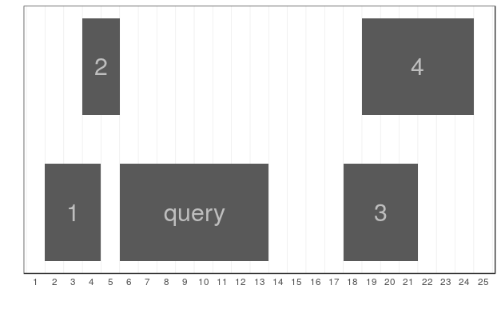

To keep precede() and follow() straight, remember that these functions are with respect to the query: precede() finds ranges that the query precedes and follow() finds ranges that the query follows. Also, illustrated in this example (seen in Figure above), the function nearest() behaves slightly differently than precede() and follow() . Unlike precede() and follow() , nearest() will return the nearest range even if it overlaps the query range. These subtleties demonstrate how vital it is to carefully read all function documentation before using libraries.

```r
follow(qry, sbj)
```

```
[1] 2
```

Note too that these operations are all vectorized, so you can provide a query IRanges object with multiple ranges:

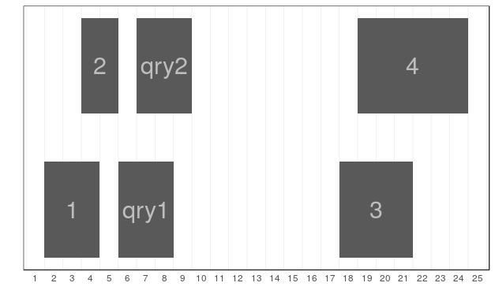

```r
nearest(qry2, sbj)
```

```
[1] 2 2
```

Now, let’s use distanceToNearest() to find neighboring ranges. It works a lot like findOverlaps() —for each query range, it finds the closest subject range, and returns everything in a Hits object with an additional column indicating the distance:

```r
distanceToNearest(qry, sbj)
```

```
Hits object with 5 hits and 1 metadata column:
      queryHits subjectHits |  distance
      <integer>   <integer> | <integer>
  [1]         1           5 |        79
  [2]         2           5 |        57
  [3]         3           1 |        46
  [4]         4           5 |       207
  [5]         5           3 |       102
  -------
  queryLength: 5 / subjectLength: 5
```

The method distance() returns each pairwise distance between query and subject ranges:

```r
distance(qry, sbj)
```

```
[1] 500 538 188 258 731
```

### Run Length Encoding and Views

The generic ranges implemented by IRanges can be ranges over any type of sequence. In the context of genomic data, these ranges’ coordinates are based on the underlying nucleic acid sequence of a particular chromosome. Yet, many other types of genomic data form a sequence of numeric values over each position of a chromosome sequence. Some examples include: • Coverage, the depth of overlap of ranges across the length of a sequence. Cover‐ age is used extensively in genomics, from being an important factor in how var‐ iants are called to being used to discover coverage peaks that indicate the presence of some feature (as in a ChIP-seq study). • Conservation tracks, which are base-by-base evolutionary conservation scores between species, generated by a program like phastCons (see Siepel et al., 2005 as an example). • Per-base pair estimates of population genomics summary statistics like nucleo‐ tide diversity.

#### Run-length encoding and coverage()

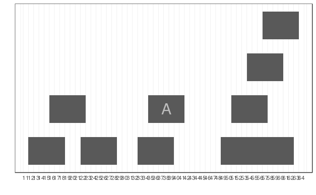

```r
# If instead we wanted the mean coverage within this range, we could simply pass the
# result to mean() :
mean(rngs_cov[rngs['A']])
```

```
[1] 1.714286
```

```r
# This object that’s returned is called a view. Views combine a run-length encoded vec‐
# tors and ranges, such that each range is a “view” of part of the sequence. In this case,
# each view is a view on to the part of the sequence that has more than 2x coverage.
# The numbers to the right of the ranges are the underlying elements of the run-length
# encoded vector in this range. If you’re simply interested in ranges, it’s easy to extract
# out the underlying ranges:
ranges(min_cov2)
```

```
IRanges object with 4 ranges and 0 metadata columns:
          start       end     width
      <integer> <integer> <integer>
  [1]        16        18         3
  [2]        22        22         1
  [3]        35        39         5
  [4]        51        62        12
```

### Advanced IRanges: Views

While they may seem a bit strange at first, views are incredibly handy. By combining a sequence vector and ranges, views simplify operations that involve aggregating a sequence vector by certain ranges. In this way, they’re similar to calculating per-group summaries as we did in Chapter 8, but groups are ranges.

For example, we could summarize the views we created earlier using slice() using functions like viewMeans() , viewMaxs() , and even viewApply() , which applies an arbitrary function to views:

```r
viewApply(min_cov2, median)
```

```
[1] 2 2 2 3
```

Each element of these returned vectors is a summary of a range’s underlying run- length encoded vector (in this case, our coverage vector min_cov2 summarized by the ranges we carved out using slice() ). Also, there are a few other built-in view sum‐ marization methods; see help(viewMeans) for a full list. Using Views , we can also create summaries of sequences by window/bin. In the views lingo, we create a set of ranges for each window along a sequence and then summa‐ rize the views onto the underlying sequence these windows create. For example, if we wanted to calculate the average coverage for windows 5-positions wide:

```r
viewMeans(cov_by_wnd)
```

```
 [1] 0.0 0.0 0.8 1.6 1.2 0.6 0.8 1.8 0.2 0.4 2.4 3.2
```

Summarizing a sequence of numeric values by window over a sequence such as a chromosome is a common task in genomics. The techniques used to implement the generic solution to this problem with ranges, run-length encoded vectors, and views are directly extensible to tackling this problem with real genomics data. Because GenomicRanges extends IRanges , everything we’ve learned in the previous sections can be directly applied to the genomic version of an IRanges object, GRanges . None of the function names nor behaviors differ much, besides two added complications: dealing with multiple chromosomes and strand. As we’ll see in the next sections, GenomicRanges manages these complications and greatly simplifies our lives when working with genomic data.

### Storing Genomic Ranges with GenomicRanges

```r
mean(mcols(gr[seqnames(gr) == "chr1"])$gc)
```

```
[1] 0.5065
```

### Grouping Data with GRangesList

```r
doubled_grl[[2]]
```

```
GRanges object with 2 ranges and 0 metadata columns:
      seqnames    ranges strand
         <Rle> <IRanges>  <Rle>
  [1]     chr8     27-68      *
  [2]     chr2     12-45      *
  -------
  seqinfo: 3 sequences from an unspecified genome; no seqlengths
```

```r
names(gr_split)
```

```
[1] "chr3" "chr1" "chr2"
```

```r
elementLengths(gr_split)
```

[output not shown]

lapply() and sapply() (as well as mapply() ) give you the most freedom to write and use your own functions to apply to data. However, for many overlap operation func‐ tions (e.g., reduce() , flank() , coverage() , and findOverlaps() ), we don’t need to explicitly apply them—they can work directly with GRangesList objects. For exam‐ ple, reduce() called on a GRangesList object automatically works at the list-element level:

```r
reduce(gr_split)
```

```
GRangesList object of length 3:
$chr3
GRanges object with 2 ranges and 0 metadata columns:
      seqnames    ranges strand
         <Rle> <IRanges>  <Rle>
  [1]     chr3     11-28      *
  [2]     chr3     65-80      *

$chr1
GRanges object with 1 range and 0 metadata columns:
      seqnames ranges strand
  [1]     chr1 73-101      *

$chr2
GRanges object with 2 ranges and 0 metadata columns:
      seqnames ranges strand
  [1]     chr2  42-66      *
  [2]     chr2  83-85      *

-------
seqinfo: 3 sequences from an unspecified genome; no seqlengths
```

reduce() illustrates an important (and extremely helpful) property of GRangesList objects: many methods applied to GRangesList objects work at the grouped-data level automatically. Had this list contained exons grouped by transcript, only overlap‐ ping exons within a list element (transcript) would be collapsed with reduce() . findO verlaps() behaves similarly; overlaps are caclulated at the list-element level. We’ll see a more detailed example of findOverlaps() with GRangesList objects once we start working with real annotation data in the next section.